# Reproducible Research Final Project

November 20, 2016

## Introduction

Storms and other severe weather events can cause both public health and economic problems for communities and municipalities. Many severe events can result in fatalities, injuries, and property damage, and preventing such outcomes to the extent possible is a key concern.

This project involves exploring the U.S. National Oceanic and Atmospheric Administration’s (NOAA) storm database. This database tracks characteristics of major storms and weather events in the United States, including when and where they occur, as well as estimates of any fatalities, injuries, and property damage.

This analysis helps us to understand the events that cause the most harm to human population health and has the most economic consequences.

##Data Processing

The data for this assignment come in the form of a comma-separated-value file compressed via the bzip2 algorithm to reduce its size. You can download the file from the course web site:

[Storm Data [47Mb]](https://d396qusza40orc.cloudfront.net/repdata%2Fdata%2FStormData.csv.bz2)  
There is also some documentation of the database available. Here you will find how some of the variables are constructed/defined.

-National Weather Service [Storm Data Documentation](https://d396qusza40orc.cloudfront.net/repdata%2Fpeer2_doc%2Fpd01016005curr.pdf)  
-National Climatic Data Center [Storm Events FAQ](https://d396qusza40orc.cloudfront.net/repdata%2Fpeer2_doc%2FNCDC%20Storm%20Events-FAQ%20Page.pdf)  
The events in the database start in the year 1950 and end in November 2011. In the earlier years of the database there are generally fewer events recorded, most likely due to a lack of good records. More recent years should be considered more complete.

```r
#downloading and reading data
library(readr)
library(knitr)
fileurl<-"https://d396qusza40orc.cloudfront.net/repdata%2Fdata%2FStormData.csv.bz2"
download.file(fileurl,"repdata%2Fdata%2FStormData.csv.bz2")
df<-read.csv("repdata%2Fdata%2FStormData.csv.bz2")
```

## Extracting the essential variables for Analysis

In this chunk we are going to extract the necessary columns from the main dataframe and make a new dataframe

```r
#creating a new DataFrame only with necessary columns
columns<-c("EVTYPE","FATALITIES","INJURIES","PROPDMG","PROPDMGEXP",
          "CROPDMG","CROPDMGEXP")
pjt<-df[columns]
```

## Computations

The values used in columns “PROPDMGEXP” and “CROPDMGEXP” aren’t capable of performing analyses. So, in the following chunk we reassign those values to meaningful numbers according to Page 12 of the [Storm Data Documentation](https://d396qusza40orc.cloudfront.net/repdata%2Fpeer2_doc%2Fpd01016005curr.pdf)

```r
unique(pjt$PROPDMGEXP)
```

```
##  [1] K M   B m + 0 5 6 ? 4 2 3 h 7 H - 1 8
## Levels:  - ? + 0 1 2 3 4 5 6 7 8 B h H K m M
```

```r
#Assigning Values to PROPDMGEXP
pjt$PROPDMGEXP<-as.character(pjt$PROPDMGEXP)
pjt$PROPDMGEXP[pjt$PROPDMGEXP=="K"]<-1000
pjt$PROPDMGEXP[pjt$PROPDMGEXP=="M"]<-1000000
pjt$PROPDMGEXP[pjt$PROPDMGEXP=="m"]<-1000000
pjt$PROPDMGEXP[pjt$PROPDMGEXP==""]<-1
pjt$PROPDMGEXP[pjt$PROPDMGEXP=="B"]<-1000000000
pjt$PROPDMGEXP[pjt$PROPDMGEXP=="0"]<-1
pjt$PROPDMGEXP[pjt$PROPDMGEXP=="5"]<-100000
pjt$PROPDMGEXP[pjt$PROPDMGEXP=="6"]<-1000000
pjt$PROPDMGEXP[pjt$PROPDMGEXP=="2"]<-100
pjt$PROPDMGEXP[pjt$PROPDMGEXP=="3"]<-1000
pjt$PROPDMGEXP[pjt$PROPDMGEXP=="4"]<-10000
pjt$PROPDMGEXP[pjt$PROPDMGEXP=="h"]<-100
pjt$PROPDMGEXP[pjt$PROPDMGEXP=="H"]<-100
pjt$PROPDMGEXP[pjt$PROPDMGEXP=="7"]<-1000000
pjt$PROPDMGEXP[pjt$PROPDMGEXP=="1"]<-10
pjt$PROPDMGEXP[pjt$PROPDMGEXP=="8"]<-10000000
pjt$PROPDMGEXP[pjt$PROPDMGEXP=="+"]<-0
pjt$PROPDMGEXP[pjt$PROPDMGEXP=="?"]<-0
pjt$PROPDMGEXP[pjt$PROPDMGEXP=="-"]<-0
pjt$PROPDMGEXP<-as.numeric(pjt$PROPDMGEXP)
```

The property damage value of computed by multiplying “PROPDMG” and “PROPDMGEXP”.

```r
#Calculating the actual Property Damage
pjt$PROPDMG_VAL<-pjt$PROPDMGEXP * pjt$PROPDMG
```

```r
unique(pjt$CROPDMGEXP)
```

```
## [1]   M K m B ? 0 k 2
## Levels:  ? 0 2 B k K m M
```

```r
pjt$CROPDMGEXP<-as.character(pjt$CROPDMGEXP)
pjt$CROPDMGEXP[pjt$CROPDMGEXP=="K"]<-1000
pjt$CROPDMGEXP[pjt$CROPDMGEXP=="k"]<-1000
pjt$CROPDMGEXP[pjt$CROPDMGEXP==""]<-1
pjt$CROPDMGEXP[pjt$CROPDMGEXP=="M"]<-1000000
pjt$CROPDMGEXP[pjt$CROPDMGEXP=="m"]<-1000000
pjt$CROPDMGEXP[pjt$CROPDMGEXP=="B"]<-1000000000
pjt$CROPDMGEXP[pjt$CROPDMGEXP=="0"]<-1
pjt$CROPDMGEXP[pjt$CROPDMGEXP=="2"]<-100
pjt$CROPDMGEXP[pjt$CROPDMGEXP=="?"]<-0
pjt$CROPDMGEXP<-as.numeric(pjt$CROPDMGEXP)
```

The crop damage value of computed by multiplying “CROPDMG” and “CROPDMGEXP”.

```r
#Calculating the actual Crop Damage
pjt$CROPDMG_VAL<-pjt$CROPDMGEXP * pjt$CROPDMG
```

```r
#Aggregating the data by sum total of the event
fatalities<-aggregate(pjt$FATALITIES~pjt$EVTYPE,pjt,FUN=sum)
injuries<-aggregate(pjt$INJURIES~pjt$EVTYPE,pjt,FUN=sum)
propertyDamage<-aggregate(pjt$PROPDMG_VAL~pjt$EVTYPE,pjt,FUN=sum)
cropDamage<-aggregate(pjt$CROPDMG_VAL~pjt$EVTYPE,pjt,FUN=sum)
```

## Results Processing

```r
#Sorting and plotting
fatalities10<-fatalities[order(-fatalities$`pjt$FATALITIES`),][1:10,]
injuries10<-injuries[order(-injuries$`pjt$INJURIES`),][1:10,]
propertyDamage10<-propertyDamage[order(-propertyDamage$`pjt$PROPDMG_VAL`),][1:10,]
cropDamage10<-cropDamage[order(-cropDamage$`pjt$CROPDMG_VAL`),][1:10,]
```

## Results

The following figures show the top 10 events that contribute the most to fatalities and injuries which represents harm to human population health.

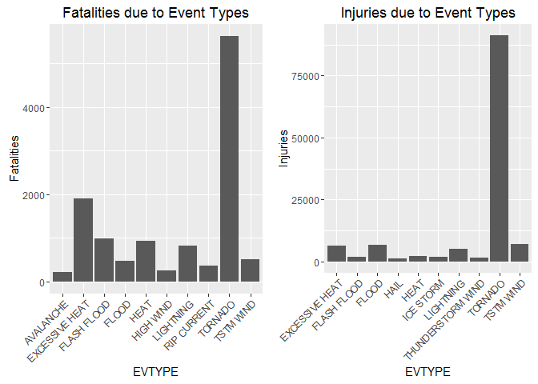

```r
library(ggplot2)
library(gridExtra)
f<-ggplot(fatalities10,aes(y=fatalities10$`pjt$FATALITIES`,x=fatalities10$`pjt$EVTYPE`))+
       geom_bar(stat="identity")+
       theme(axis.text.x=element_text(angle=45, hjust=1))+
       labs(x="EVTYPE")+labs(y="Fatalities")+
       labs(title="Fatalities due to Event Types")
i<-ggplot(injuries10,aes(y=injuries10$`pjt$INJURIES`,x=injuries10$`pjt$EVTYPE`))+
  geom_bar(stat="identity")+
  theme(axis.text.x=element_text(angle=45, hjust=1))+
  labs(x="EVTYPE")+labs(y="Injuries")+
  labs(title="Injuries due to Event Types")
grid.arrange(f,i,ncol=2)
```

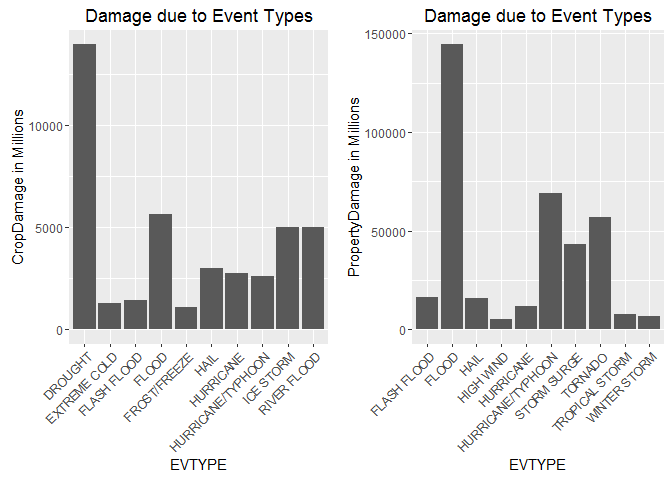

```r
c<-ggplot(cropDamage10,aes(y=(cropDamage10$`pjt$CROPDMG_VAL`)/1000000,x=cropDamage10$`pjt$EVTYPE`))+
  geom_bar(stat="identity")+
  theme(axis.text.x=element_text(angle=45, hjust=1))+
  labs(x="EVTYPE")+labs(y="CropDamage in Millions")+
  labs(title="Damage due to Event Types")

p<-ggplot(propertyDamage10,aes(y=(propertyDamage10$`pjt$PROPDMG_VAL`)/1000000,x=propertyDamage10$`pjt$EVTYPE`))+
  geom_bar(stat="identity")+
  theme(axis.text.x=element_text(angle=45, hjust=1))+
  labs(x="EVTYPE")+labs(y="PropertyDamage in Millions")+
  labs(title="Damage due to Event Types")
grid.arrange(c,p,ncol=2)
```

It is clear from the above figures that Floods cause the highest property damage and Droughts cause the highest crop damage.